# Untitled

## Q1

```r
res2 <- rcorr(as.matrix(house[,sapply(house,is.numeric)] ), type = c("pearson","spearman"))
data.frame(abs(res2$r)) %>% rownames_to_column() %>% select(SalePrice,rowname)  %>% arrange(desc(SalePrice)) %>% head(11)
```

```
##    SalePrice      rowname
## 1  1.0000000    SalePrice
## 2  0.7909816  OverallQual
## 3  0.7086245    GrLivArea
## 4  0.6404092   GarageCars
## 5  0.6234314   GarageArea
## 6  0.6135806  TotalBsmtSF
## 7  0.6058522     1stFlrSF
## 8  0.5606638     FullBath
## 9  0.5337232 TotRmsAbvGrd
## 10 0.5228973    YearBuilt
## 11 0.5071010 YearRemodAdd
```

## Q2

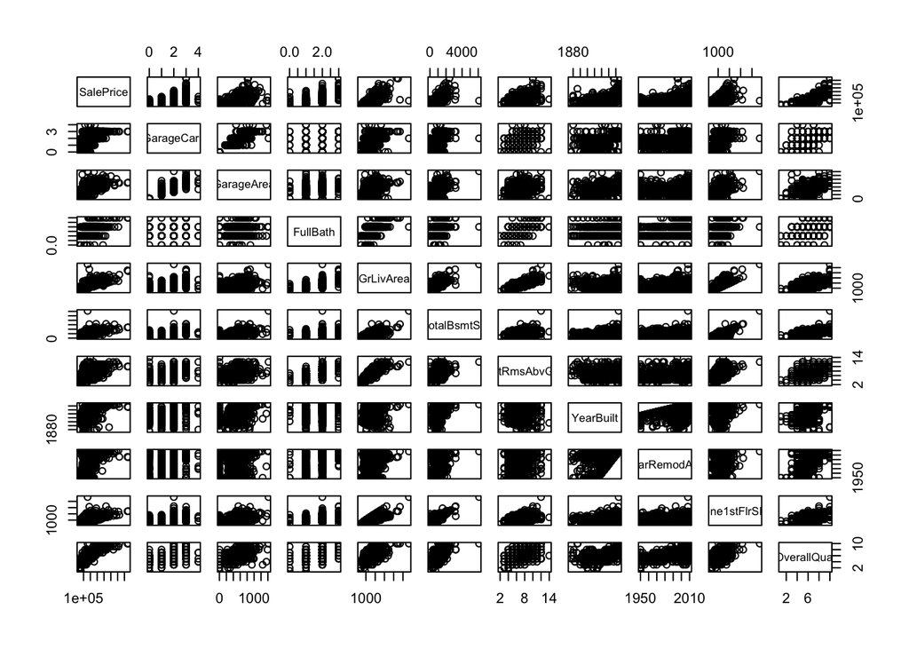

```r
colnames(house)[44]<-"one1stFlrSF"
tentop <- house %>% select(SalePrice,GarageCars,GarageArea,FullBath,GrLivArea,TotalBsmtSF,TotRmsAbvGrd,YearBuilt,YearRemodAdd,one1stFlrSF,OverallQual)
plot(tentop)
```

## Q3

```r
fittedPrice = lm(SalePrice ~ GrLivArea + GarageCars + OverallQual + YearBuilt + YearRemodAdd +  TotRmsAbvGrd + GarageArea + FullBath+ TotalBsmtSF + one1stFlrSF, data = house)
summary(fittedPrice)
```

```
##
## Call:
## lm(formula = SalePrice ~ GrLivArea + GarageCars + OverallQual +
##     YearBuilt + YearRemodAdd + TotRmsAbvGrd + GarageArea + FullBath +
##     TotalBsmtSF + one1stFlrSF, data = house)
##
## Residuals:
##     Min      1Q  Median      3Q     Max
## -489958  -19316   -1948   16020  290558
##
## Coefficients:
##                Estimate Std. Error t value Pr(>|t|)
## (Intercept)  -1.186e+06  1.291e+05  -9.187  < 2e-16 ***
## GrLivArea     5.130e+01  4.233e+00  12.119  < 2e-16 ***
## GarageCars    1.042e+04  3.044e+03   3.422 0.000639 ***
## OverallQual   1.960e+04  1.190e+03  16.472  < 2e-16 ***
## YearBuilt     2.682e+02  5.035e+01   5.328 1.15e-07 ***
## YearRemodAdd  2.965e+02  6.363e+01   4.659 3.47e-06 ***
## TotRmsAbvGrd  3.310e+01  1.119e+03   0.030 0.976404
## GarageArea    1.495e+01  1.031e+01   1.450 0.147384
## FullBath     -6.791e+03  2.682e+03  -2.532 0.011457 *
## TotalBsmtSF   1.986e+01  4.295e+00   4.625 4.09e-06 ***
## one1stFlrSF   1.417e+01  4.930e+00   2.875 0.004097 **
## ---
## Signif. codes:  0 '***' 0.001 '**' 0.01 '*' 0.05 '.' 0.1 ' ' 1
##
## Residual standard error: 37920 on 1449 degrees of freedom
## Multiple R-squared:  0.7737, Adjusted R-squared:  0.7721
## F-statistic: 495.4 on 10 and 1449 DF,  p-value: < 2.2e-16
```

## Q4

According to Residual vs Fitted plot, We can predict non-zero and big value of residual when our fitted value is large. for example when our fitted value is near 4e+05 we expect a non-zero residual near 2e^05 so our predictores are unable to explain the function compeletly. According to second plot, Normal Q-Q we can conclude that our errors do not follor normal distribution.

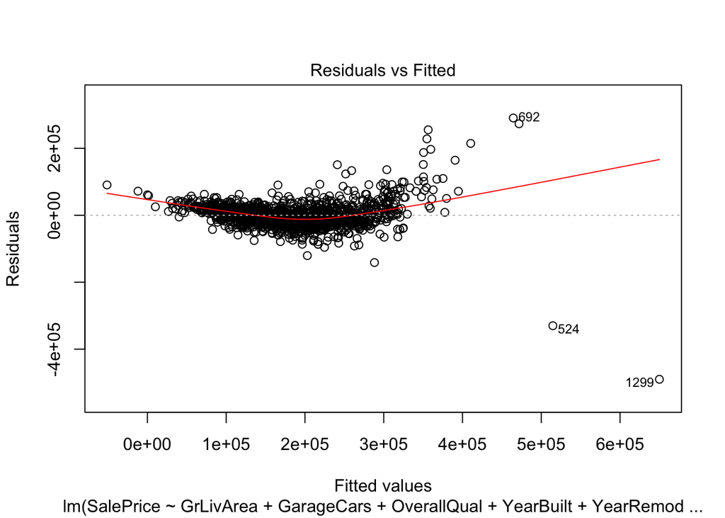

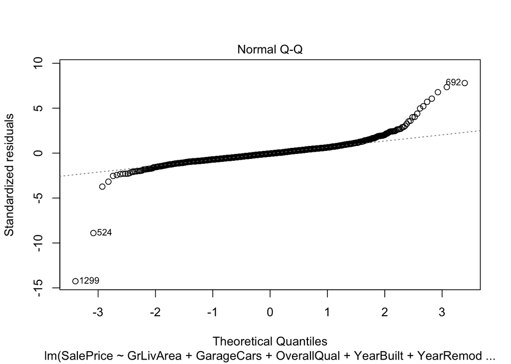

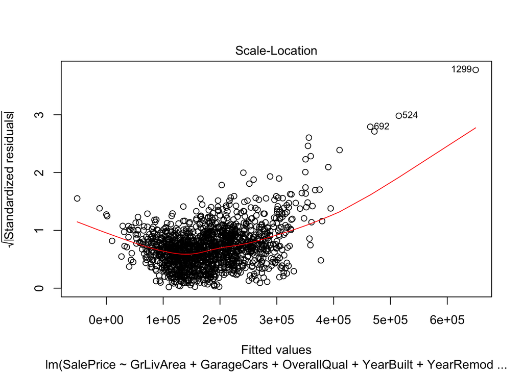

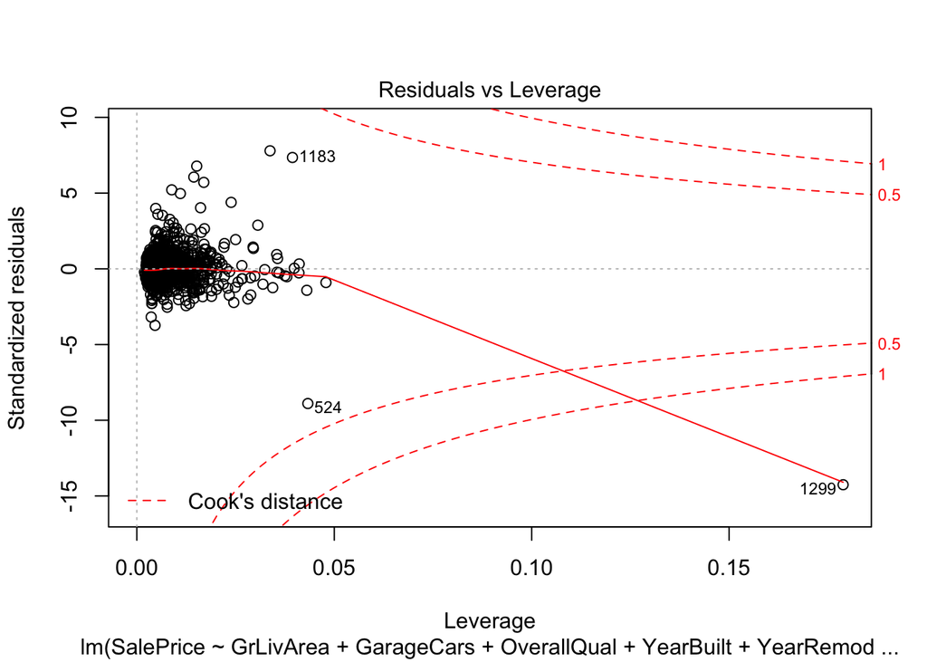

```r
plot(fittedPrice)
```

## Q5

r-squared shows us how much our data is close to fitted regression. the value of R squared is 77 percent and thus only 77 percent of the variance found in the response variable can be explained by predictors. and According to value of f statistics is much larger than 1 SalePrice depends on the predictors.

```r
summary(fittedPrice)$r.squared
```

```
## [1] 0.7736928
```

```r
summary(fittedPrice)$fstatistic
```

```
##     value     numdf     dendf
##  495.3802   10.0000 1449.0000
```

## Q6

I deleted GarageArea and TotRmsAbvGrd because their p-values were higher than 0.05.

```r
revisedFittedPrice = lm(SalePrice ~ GrLivArea + GarageCars + OverallQual + YearBuilt + YearRemodAdd  + FullBath+ TotalBsmtSF + one1stFlrSF, data = house)
summary(revisedFittedPrice)
```

```
##
## Call:
## lm(formula = SalePrice ~ GrLivArea + GarageCars + OverallQual +
##     YearBuilt + YearRemodAdd + FullBath + TotalBsmtSF + one1stFlrSF,
##     data = house)
##
## Residuals:
##     Min      1Q  Median      3Q     Max
## -482525  -19191   -1801   16208  289639
##
## Coefficients:
##                Estimate Std. Error t value Pr(>|t|)
## (Intercept)  -1.188e+06  1.284e+05  -9.255  < 2e-16 ***
## GrLivArea     5.177e+01  3.097e+00  16.714  < 2e-16 ***
## GarageCars    1.395e+04  1.817e+03   7.680 2.92e-14 ***
## OverallQual   1.959e+04  1.188e+03  16.486  < 2e-16 ***
## YearBuilt     2.699e+02  5.017e+01   5.380 8.69e-08 ***
## YearRemodAdd  2.957e+02  6.362e+01   4.649 3.64e-06 ***
## FullBath     -7.184e+03  2.644e+03  -2.717  0.00666 **
## TotalBsmtSF   2.039e+01  4.269e+00   4.775 1.98e-06 ***
## one1stFlrSF   1.465e+01  4.919e+00   2.979  0.00294 **
## ---
## Signif. codes:  0 '***' 0.001 '**' 0.01 '*' 0.05 '.' 0.1 ' ' 1
##
## Residual standard error: 37920 on 1451 degrees of freedom
## Multiple R-squared:  0.7734, Adjusted R-squared:  0.7721
## F-statistic: 618.9 on 8 and 1451 DF,  p-value: < 2.2e-16
```

## Q7

From ACF plot we can conclude that our residuals are not autocorrelated. it shows that our instances are independence. Residual VS fitted and Q-Q normal plots are same as Question number 4.

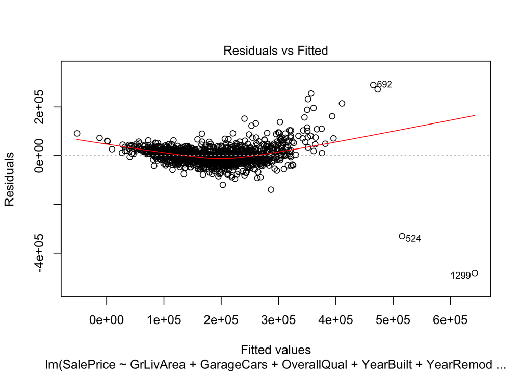

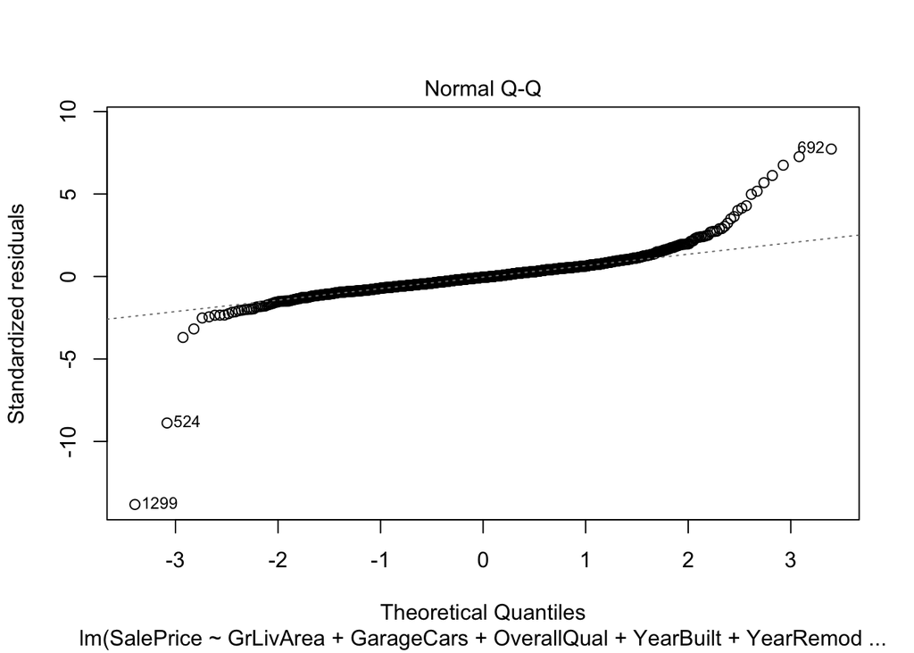

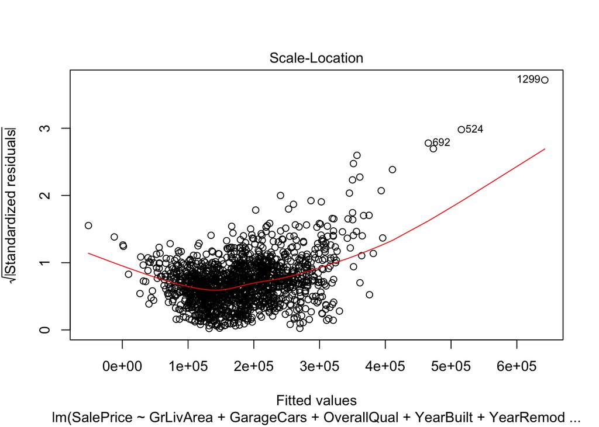

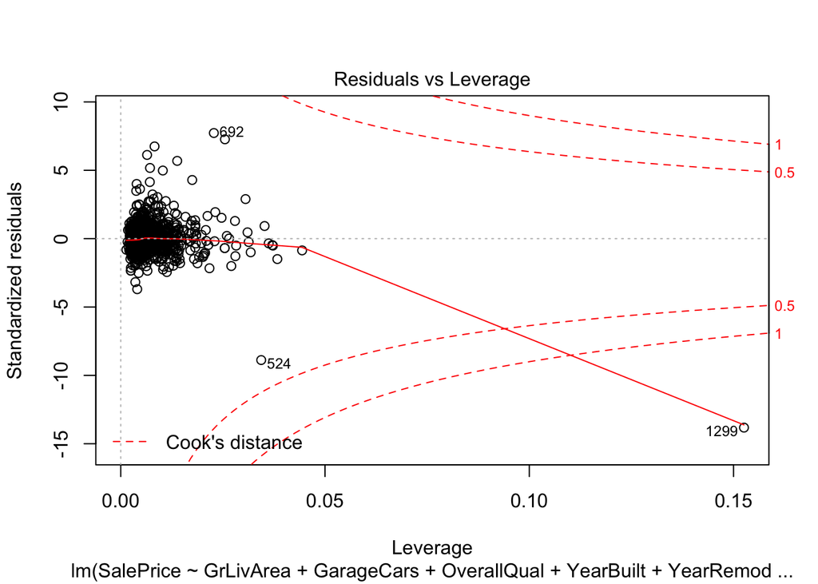

```r
plot(revisedFittedPrice)
```

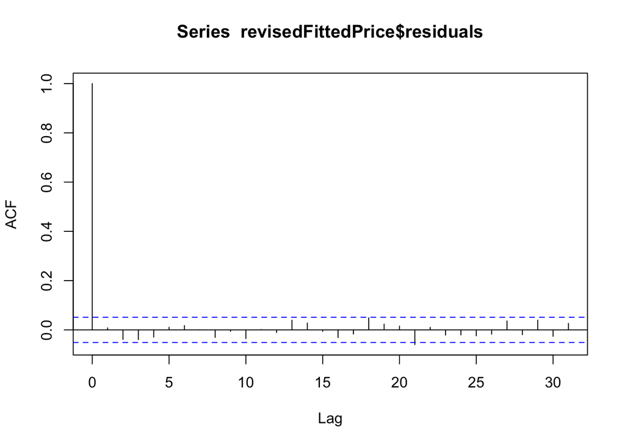

```r
acf(revisedFittedPrice$residuals)
```

## Q8

```r
library(caret)
train_control <- trainControl(method="cv", number=5)
model <- train(SalePrice ~ GrLivArea + GarageCars + OverallQual + YearBuilt + YearRemodAdd  + FullBath+ TotalBsmtSF + one1stFlrSF, data=tentop, trControl=train_control, method="lm")
print(model)
```

```
## Linear Regression
##
## 1460 samples
##    8 predictor
##
## No pre-processing
## Resampling: Cross-Validated (5 fold)
## Summary of sample sizes: 1168, 1168, 1169, 1166, 1169
## Resampling results:
##
##   RMSE      Rsquared   MAE
##   38830.83  0.7661874  24363.25
##
## Tuning parameter 'intercept' was held constant at a value of TRUE
```

## Q9

According to scatterplots of we can guess that some relations are not linear and then change them with the most likely equation.

```r
veryrevisedFittedPrice = lm(SalePrice ~ GrLivArea^2 + GarageCars^2 + exp(OverallQual) + YearBuilt^2 + YearRemodAdd^2   + TotalBsmtSF^2 + one1stFlrSF^2, data = house)
summary(veryrevisedFittedPrice)
```

```
##
## Call:
## lm(formula = SalePrice ~ GrLivArea^2 + GarageCars^2 + exp(OverallQual) +
##     YearBuilt^2 + YearRemodAdd^2 + TotalBsmtSF^2 + one1stFlrSF^2,
##     data = house)
##
## Residuals:
##     Min      1Q  Median      3Q     Max
## -574820  -16431   -2551   13740  246996
##
## Coefficients:
##                    Estimate Std. Error t value Pr(>|t|)
## (Intercept)      -1.652e+06  1.098e+05 -15.050  < 2e-16 ***
## GrLivArea         5.481e+01  2.504e+00  21.887  < 2e-16 ***
## GarageCars        1.724e+04  1.761e+03   9.791  < 2e-16 ***
## exp(OverallQual)  7.882e+00  4.391e-01  17.950  < 2e-16 ***
## YearBuilt         4.085e+02  4.565e+01   8.950  < 2e-16 ***
## YearRemodAdd      4.406e+02  6.071e+01   7.256 6.45e-13 ***
## TotalBsmtSF       2.333e+01  4.152e+00   5.620 2.29e-08 ***
## one1stFlrSF       4.758e+00  4.821e+00   0.987    0.324
## ---
## Signif. codes:  0 '***' 0.001 '**' 0.01 '*' 0.05 '.' 0.1 ' ' 1
##
## Residual standard error: 37420 on 1452 degrees of freedom
## Multiple R-squared:  0.7791, Adjusted R-squared:  0.7781
## F-statistic: 731.8 on 7 and 1452 DF,  p-value: < 2.2e-16
```

## Q10

```r
test = read.csv("~/Downloads/house/test.csv")
colnames(test)[44]<-"one1stFlrSF"

predict<- data.frame(test$Id)
predict$SalePrice <- predict(veryrevisedFittedPrice, test)
colnames(predict) <- c("Id", "SalePrice")
predict[is.na(predict)] <- 178680
write_csv(predict,"predict.csv")
```